# Data challenge

Ricki Ricardo

2021-02-27

# Example 1

## Eyeball the data

```r
mean(df_sales$order_amount)
```

```
[1] 3145.128
```

## Check for extreme values

```r
# min / max for order_amount
cat("order_amount\n",sep="\n")
summary(df_sales$order_amount)
cat("Standard Deviation: ",sd(df_sales$order_amount))

cat("\n",sep="\n")

#min / max for total_items
cat("total_items\n",sep="\n")
summary(df_sales$total_items)
cat("Standard Deviation: ",sd(df_sales$total_items))
```

```
order_amount

   Min. 1st Qu.  Median    Mean 3rd Qu.    Max.
     90     163     284    3145     390  704000
Standard Deviation:  41282.54

total_items

    Min.  1st Qu.   Median     Mean  3rd Qu.     Max.
   1.000    1.000    2.000    8.787    3.000 2000.000
Standard Deviation:  116.3203
```

According to our exploration of the ‘ordered_amount’ and ‘total_items’:

The minimum amount of money of an online order is $90, and the maximum amount is $704 000  
The minimum amount of sneakers of an online order is 1, and the maximum amount is 2000

The Average order value(AOV) we discovered was $3145.13, and indeed our summary table also shows this to be the case. Something additionally alarming about **order_amount** is that the standard deviation claims that values vary $41 282.54 from the mean! While the 3rd Quartile is $390, the maximum value is $704 000, this tells us that the mean is not a useful measure of central tendency because a few outliers are almost certainly skewing it; **in cases such as these, the median is a better measure of central tendency**. **total_items** is not as alarming as **order_amount**, however, since the median is 2 items, and the max is 2000, again, the mean is most likely being skewed by outliers.

## Visualizations

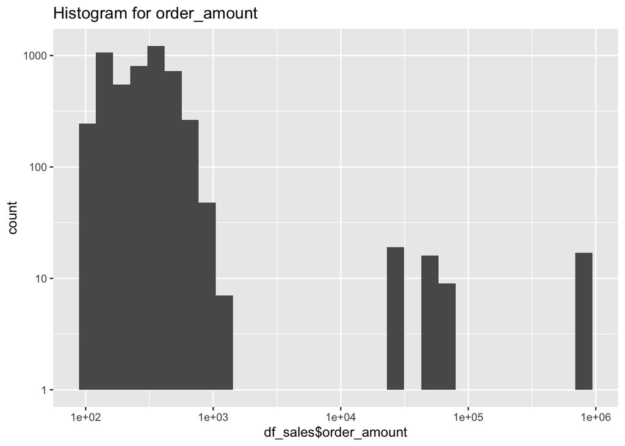

```r
#histogram
gg$ggplot(data=df_sales, mapping = gg$aes(df_sales$order_amount))+ gg$geom_histogram(bindwidth=30) + gg$scale_y_log10() + gg$scale_x_log10() +gg$ggtitle("Histogram for order_amount")
```

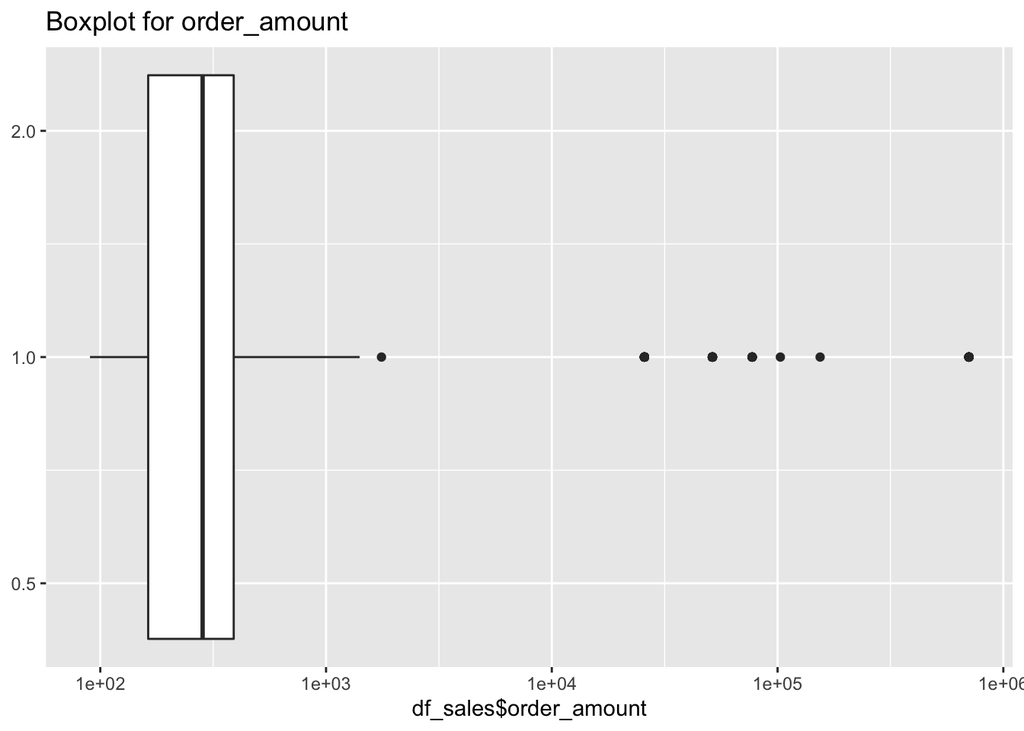

```r
#boxplot
gg$ggplot(data=df_sales, mapping = gg$aes(df_sales$order_amount))+ gg$geom_boxplot() + gg$scale_y_log10() + gg$scale_x_log10() +gg$ggtitle("Boxplot for order_amount")
```

## Frequency counts of Quartiles

**Using the 5 point summary from earlier:** IQR = Q3 - Q1  
IQR = 390 - 163  
IQR = 227

227 X 1.5 = 340.5

**Frequency Counts**

```r
library("plyr")
count(df_sales$order_amount)
```

```
         x freq
1       90   18
2       94   25
3      101   15
4      111   16
5      112   48
6      114   27
7      116   23
8      117   29
9      118   43
10     122   21
11     127   22
12     128   30
13     129   50
14     130   52
```

[output cut: 244 more lines]

**Frequency Counts of Quartiles with top +/- 5% removed**

```r
#x<-list(df_sales$order_amount)
QR_1 <- length(which(df_sales$order_amount>= 117.5 & df_sales$order_amount<=163))
QR_2 <- length(which(df_sales$order_amount>163 & df_sales$order_amount<=284 ))
QR_3 <- length(which(df_sales$order_amount>284 & df_sales$order_amount <= 390))
QR_4 <- length(which(df_sales$order_amount>390 & df_sales$order_amount <= 730))
outliers <- length(which(df_sales$order_amount > 730))

reporting_freq <-cat("***Frequencies of order_amount***\n","Frequencies-QR 1(-95%):  ",QR_1,"\n","Frequencies-QR 2:  ",QR_2,"\n","Frequencies-QR 3:  ",QR_3,"\n","Frequencies-QR 4(+95%):  ",QR_4,"\n","Outliers(<+5%):  ",outliers,"\n",sep="\n")

reporting_freq

#length(df_sales$order_amount)
```

```
***Frequencies of order_amount***

Frequencies-QR 1(-95%):
1061


Frequencies-QR 2:
1249


Frequencies-QR 3:
1242


Frequencies-QR 4(+95%):
1106


Outliers(<+5%):
141


NULL
```

## closer look at outliers

Wow, according to our frequency counts we have a total of 141 outliers exceeding in the top 5%!  
Let us take a closer look at what our outliers are.

```r
table( df_sales$order_amount>730)
```

```
FALSE  TRUE
 4859   141
```

Looking at the frequency counts in the previous section notice how:  
$25 725 is repeated 19 times  
$51 450 is repeated 16 times  
$77 175 is repeated 9 times  
$704 000 is repeated 17 times

These are the values which are driving our means so high! One may wonder how and why these same large values repeat themselves so often when the median of $284 is so much lower. Perhaps a cross comparison with other variables in our dataset may elucidate this conundrum?

**Filtered for $25 725**

```r
dplyr::filter(df_sales,df_sales$order_amount == 25725)

# include 'created_at' in output
a1<-dplyr::filter(df_sales,df_sales$order_amount == 25725)
a2<-a1[7]
a2
```

```
# A tibble: 19 x 7
   order_id shop_id user_id order_amount total_items payment_method created_at
      <int>   <int>   <int>        <dbl>       <int> <fct>          <dttm>
 1      161      78     990        25725           1 credit_card    2017-03-09 20:56:00
 2     1057      78     800        25725           1 debit          2017-03-13 13:16:00
 3     1194      78     944        25725           1 debit          2017-03-15 14:38:00
 4     1205      78     970        25725           1 credit_card    2017-03-17 01:32:00
 5     1385      78     867        25725           1 cash           2017-03-17 10:38:00
 6     1420      78     912        25725           1 cash           2017-03-28 17:23:00
 7     1453      78     812        25725           1 credit_card    2017-03-15 12:09:00
 8     2271      78     855        25725           1 credit_card    2017-03-14 01:58:00
 9     2549      78     861        25725           1 cash           2017-03-17 19:36:00
10     2774      78     890        25725           1 cash           2017-03-24 15:36:00
11     2923      78     740        25725           1 debit          2017-03-10 10:10:00
12     3086      78     910        25725           1 cash           2017-03-24 22:59:00
```

[output cut: 29 more lines]

**Filtered for $51 450**

```r
dplyr::filter(df_sales,df_sales$order_amount == 51450)

# include 'created_at' in output
b1<-dplyr::filter(df_sales,df_sales$order_amount == 51450)
b2<-b1[7]
b2
```

```
# A tibble: 16 x 7
   order_id shop_id user_id order_amount total_items payment_method created_at
      <int>   <int>   <int>        <dbl>       <int> <fct>          <dttm>
 1      491      78     936        51450           2 debit          2017-03-25 22:08:00
 2      494      78     983        51450           2 cash           2017-03-15 10:39:00
 3      512      78     967        51450           2 cash           2017-03-08 17:23:00
 4      618      78     760        51450           2 cash           2017-03-16 17:18:00
 5     1530      78     810        51450           2 cash           2017-03-29 06:12:00
 6     2453      78     709        51450           2 cash           2017-03-27 07:04:00
 7     2496      78     707        51450           2 cash           2017-03-24 00:38:00
 8     2513      78     935        51450           2 debit          2017-03-18 05:57:00
 9     2819      78     869        51450           2 debit          2017-03-15 03:25:00
10     2822      78     814        51450           2 cash           2017-03-01 16:13:00
11     3102      78     855        51450           2 credit_card    2017-03-19 19:10:00
12     3168      78     927        51450           2 cash           2017-03-12 04:23:00
```

[output cut: 23 more lines]

**Filtered for $77 175**

```r
dplyr::filter(df_sales,df_sales$order_amount == 77175)

# include 'created_at' in output
c1<-dplyr::filter(df_sales,df_sales$order_amount == 77175)
c2<-c1[7]
c2
```

```
# A tibble: 9 x 7
  order_id shop_id user_id order_amount total_items payment_method created_at
     <int>   <int>   <int>        <dbl>       <int> <fct>          <dttm>
1     1260      78     775        77175           3 credit_card    2017-03-26 13:27:00
2     2565      78     915        77175           3 debit          2017-03-23 14:19:00
3     2691      78     962        77175           3 debit          2017-03-21 06:33:00
4     2907      78     817        77175           3 debit          2017-03-14 05:45:00
5     3404      78     928        77175           3 debit          2017-03-16 04:45:00
6     3725      78     766        77175           3 credit_card    2017-03-15 12:13:00
7     4193      78     787        77175           3 credit_card    2017-03-17 01:25:00
8     4421      78     969        77175           3 debit          2017-03-08 04:21:00
9     4716      78     818        77175           3 debit          2017-03-03 09:10:00
# A tibble: 9 x 1
  created_at
  <dttm>
1 2017-03-26 13:27:00
2 2017-03-23 14:19:00
3 2017-03-21 06:33:00
4 2017-03-14 05:45:00
5 2017-03-16 04:45:00
6 2017-03-15 12:13:00
7 2017-03-17 01:25:00
8 2017-03-08 04:21:00
9 2017-03-03 09:10:00
```

**Filtered for $704 000**

```r
dplyr::filter(df_sales,df_sales$order_amount == 704000)

# include 'created_at' in output
d1<-dplyr::filter(df_sales,df_sales$order_amount == 704000)
d2<-d1[7]
d2
```

```
# A tibble: 17 x 7
   order_id shop_id user_id order_amount total_items payment_method created_at
      <int>   <int>   <int>        <dbl>       <int> <fct>          <dttm>
 1       16      42     607       704000        2000 credit_card    2017-03-07 04:00:00
 2       61      42     607       704000        2000 credit_card    2017-03-04 04:00:00
 3      521      42     607       704000        2000 credit_card    2017-03-02 04:00:00
 4     1105      42     607       704000        2000 credit_card    2017-03-24 04:00:00
 5     1363      42     607       704000        2000 credit_card    2017-03-15 04:00:00
 6     1437      42     607       704000        2000 credit_card    2017-03-11 04:00:00
 7     1563      42     607       704000        2000 credit_card    2017-03-19 04:00:00
 8     1603      42     607       704000        2000 credit_card    2017-03-17 04:00:00
 9     2154      42     607       704000        2000 credit_card    2017-03-12 04:00:00
10     2298      42     607       704000        2000 credit_card    2017-03-07 04:00:00
11     2836      42     607       704000        2000 credit_card    2017-03-28 04:00:00
12     2970      42     607       704000        2000 credit_card    2017-03-28 04:00:00
```

[output cut: 25 more lines]

How interesting, many of our “frequent outier’s” share commonalities, let us explore them!

## Shop_id : 78 ($25 725, $51 450, $77 175)

Notice how for the values of $25 725, $51 450, and $77 175 all vary in **user_id** which tells us that different people bought sneakers of this value. However, for each order of the three totals were sold by the same **shop_id (78)**! This tells us that what might be happening is that shop_id 78 is acting as a mass sneaker supplier to other stores. This point is furthure supported by the **total_items** columns in each table. The total of $25 725 is tallied to a total of one item, $51 450 is two items, and $77 175 is considered three items; this makes sense if the standard bulk deal this supplier (store_id 78) offers is a certain amount of sneakers for the price of $25 725; $25 725 x 2 = $51 450 ; $25 725 x 3 = $77 175.

## Summary

To review our analyses, we originally began with the question as to why the average order value (AOV) across all our sneaker shop orders over the span of 30 days was an alarming $3145.13!

In an attempt to **investigate what could have gone wrong with this data** we checked for extreme values by displaying what is often called a five point summary (minimum value, 1st quartile , median, 3rd quartile, and highest score) of **order_amount** and **total_items** , along with each respective categories mean and standard deviation. We found that means, standard deviations, and max values were abnormally high. This suggested to us that outliers were almost certainly pulling the averages and standard deviations, and so also emphasized the median as an **alternate statistics to report for this dataset** for a more accurate assessment.

To better examine our suspicions we created visualzations using ggplot. Our histogram did indeed show a positive skew indicating outliers, and our boxplot confirmed this.

Using the five point summary we had extracted, we calculated both the interquartile range, and what the +/- 95% confidence intervals would be. Once this was done, it allowed us to display frequency counts for each quartile, and any values surpassing our +/- 95% percentiles. Upon close inspection of our frequency counts we found a total of 141 outliers exceeding +95%! What was interesting about these outliers was that specific values were repeated many times. It is because of these outliers that our mean was unreliable, and medians provided better evaluations.

- $25 725 is repeated 19 times
- $51 450 is repeated 16 times
- $77 175 is repeated 9 times
- $704 000 is repeated 17 times

These values were then each filtered to examine their relationships with other categories: order_id, shop_id, user_id, payment_method, and created_at. Interestingly our outliers shared commonalities!

For all extreme values excluding $704 000, the shop_id was 78. We suggested that this might be shop_id 78 may be acting as a bulk supplier of sneakers, with each value increment representing an additional order of bulk sneakers - made apparent by how they increase by the same exact value.

# Example 2

# Exploratory data analysis

## Exploring maximums and minimums

```r
df_sales %>%
    dp$summarize(maxOrderamount = max(order_amount), minOrderamount = min(order_amount), meanOrderamount = mean(order_amount), sdOrderamount = sd(order_amount), maxTotalitems = max(total_items), minTotalitems = min(total_items), meanTotalitems = mean(total_items), sdTotalitems = sd(total_items))
```

```
# A tibble: 1 x 8
  maxOrderamount minOrderamount meanOrderamount sdOrderamount maxTotalitems minTotalitems meanTotalitems
           <dbl>          <dbl>           <dbl>         <dbl>         <int>         <int>          <dbl>
1         704000             90           3145.        41283.          2000             1           8.79
# … with 1 more variable: sdTotalitems <dbl>
```

There appears to be extreme outliers in the maximum `order_amount` and maximum `total_items` columns as we can also confirm from the extreme standard deviation values. Therefore, I will use scatterplot to visualize these outliers

…

# Alternate Statistics & Their Values

## Examining Payment Methods

I will now examine `payment_method` to see if there are variations between cash, credit_card and debit within the data. For this, I will `summarize` the maximum, minimum, mean and standard deviation for the `order_amount` and `total_sales`.

```r
df_sales_cash <- df_sales %>%
  dp$filter(payment_method == "cash") %>%
  dp$summarize(maxOrderamountCash = max(order_amount), minOrderamountCash = min(order_amount), meanOrderamountCash = mean(order_amount), sdOrderamountCash = sd(order_amount), maxTotalitemsCash = max(total_items), minTotalitemsCash = min(total_items), meanTotalitemsCash = mean(total_items), sdTotalitemsCash = sd(total_items))
df_sales_cash

df_sales_credit_card <- df_sales %>%
  dp$filter(payment_method == "credit_card") %>%
  dp$summarize(maxOrderamountCredit = max(order_amount), minOrderamountCredit = min(order_amount), meanOrderamountCredit = mean(order_amount), sdOrderamountCredit = sd(order_amount), maxTotalitemsCredit = max(total_items), minTotalitemsCredit = min(total_items), meanTotalitemsCredit = mean(total_items), sdTotalitemsCredit = sd(total_items))
df_sales_credit_card

df_sales_debit <- df_sales %>%
  dp$filter(payment_method == "debit") %>%
  dp$summarize(maxOrderamountDebit = max(order_amount), minOrderamountDebit = min(order_amount), meanOrderamountDebit = mean(order_amount), sdOrderamountDebit = sd(order_amount), maxTotalitemsDebit = max(total_items), minTotalitemsDebit = min(total_items), meanTotalitemsDebit = mean(total_items), sdTotalitems = sd(total_items))
df_sales_debit
```

```
# A tibble: 1 x 8
  maxOrderamountCa… minOrderamountCa… meanOrderamountC… sdOrderamountCa… maxTotalitemsCa… minTotalitemsCa…
              <dbl>             <dbl>             <dbl>            <dbl>            <int>            <int>
1             51450                90              730.            4275.                6                1
# … with 2 more variables: meanTotalitemsCash <dbl>, sdTotalitemsCash <dbl>
# A tibble: 1 x 8
  maxOrderamountCr… minOrderamountCr… meanOrderamountC… sdOrderamountCr… maxTotalitemsCr… minTotalitemsCr…
              <dbl>             <dbl>             <dbl>            <dbl>            <int>            <int>
1            704000                90             7462.           69417.             2000                1
# … with 2 more variables: meanTotalitemsCredit <dbl>, sdTotalitemsCredit <dbl>
# A tibble: 1 x 8
  maxOrderamountDe… minOrderamountDe… meanOrderamountD… sdOrderamountDe… maxTotalitemsDe… minTotalitemsDe…
              <dbl>             <dbl>             <dbl>            <dbl>            <int>            <int>
1            154350                90              967.            7148.                8                1
# … with 2 more variables: meanTotalitemsDebit <dbl>, sdTotalitems <dbl>
```

Because I utilized the `df_sales` dataset, the results were skewed (as can be seen by the mean and standard deviation) as they included the outliers we had previously identified in this assignment. Therefore, I will re-evaluate the maximum, minimum, mean and standard deviation for the `order_amount` and `total_sales` using the dataset `df_sales_withoutOutliers`.

```r
df_sales_cash <- df_sales_withoutOutliers %>%
  dp$filter(payment_method == "cash") %>%
  dp$summarize(maxOrderamountCash = max(order_amount), minOrderamountCash = min(order_amount), meanOrderamountCash = mean(order_amount), sdOrderamountCash = sd(order_amount), maxTotalitemsCash = max(total_items), minTotalitemsCash = min(total_items), meanTotalitemsCash = mean(total_items), sdTotalitemsCash = sd(total_items))
df_sales_cash

df_sales_credit_card <- df_sales_withoutOutliers %>%
  dp$filter(payment_method == "credit_card") %>%
  dp$summarize(maxOrderamountCredit = max(order_amount), minOrderamountCredit = min(order_amount), meanOrderamountCredit = mean(order_amount), sdOrderamountCredit = sd(order_amount), maxTotalitemsCredit = max(total_items), minTotalitemsCredit = min(total_items), meanTotalitemsCredit = mean(total_items), sdTotalitemsCredit = sd(total_items))
df_sales_credit_card

df_sales_debit <- df_sales_withoutOutliers %>%
  dp$filter(payment_method == "debit") %>%
  dp$summarize(maxOrderamountDebit = max(order_amount), minOrderamountDebit = min(order_amount), meanOrderamountDebit = mean(order_amount), sdOrderamountDebit = sd(order_amount), maxTotalitemsDebit = max(total_items), minTotalitemsDebit = min(total_items), meanTotalitemsDebit = mean(total_items), sdTotalitems = sd(total_items))
df_sales_debit
```

```
# A tibble: 1 x 8
  maxOrderamountCa… minOrderamountCa… meanOrderamountC… sdOrderamountCa… maxTotalitemsCa… minTotalitemsCa…
              <dbl>             <dbl>             <dbl>            <dbl>            <int>            <int>
1              1760                90              298.             160.                6                1
# … with 2 more variables: meanTotalitemsCash <dbl>, sdTotalitemsCash <dbl>
# A tibble: 1 x 8
  maxOrderamountCr… minOrderamountCr… meanOrderamountC… sdOrderamountCr… maxTotalitemsCr… minTotalitemsCr…
              <dbl>             <dbl>             <dbl>            <dbl>            <int>            <int>
1              1056                90              301.             159.                6                1
# … with 2 more variables: meanTotalitemsCredit <dbl>, sdTotalitemsCredit <dbl>
# A tibble: 1 x 8
  maxOrderamountDe… minOrderamountDe… meanOrderamountD… sdOrderamountDe… maxTotalitemsDe… minTotalitemsDe…
              <dbl>             <dbl>             <dbl>            <dbl>            <int>            <int>
1              1408                90              308.             163.                8                1
# … with 2 more variables: meanTotalitemsDebit <dbl>, sdTotalitems <dbl>
```

…

# Summary

…

# Example 3

#1. EXPLORING THE DATA

To have a quick look at the data

```r
# Not a good idea in report
# View(df_sales)
```

To summarize the whole data

```r
summary(df_sales)
```

```
    order_id       shop_id          user_id       order_amount     total_items           payment_method
 Min.   :   1   Min.   :  1.00   Min.   :607.0   Min.   :    90   Min.   :   1.000   cash       :1594
 1st Qu.:1251   1st Qu.: 24.00   1st Qu.:775.0   1st Qu.:   163   1st Qu.:   1.000   credit_card:1735
 Median :2500   Median : 50.00   Median :849.0   Median :   284   Median :   2.000   debit      :1671
 Mean   :2500   Mean   : 50.08   Mean   :849.1   Mean   :  3145   Mean   :   8.787
 3rd Qu.:3750   3rd Qu.: 75.00   3rd Qu.:925.0   3rd Qu.:   390   3rd Qu.:   3.000
 Max.   :5000   Max.   :100.00   Max.   :999.0   Max.   :704000   Max.   :2000.000
   created_at
 Min.   :2017-02-26 14:09:00
 1st Qu.:2017-03-07 03:11:45
 Median :2017-03-14 21:27:00
 Mean   :2017-03-14 17:11:33
 3rd Qu.:2017-03-22 09:03:30
 Max.   :2017-03-30 16:53:00
```

To get the structure of the data

```r
str(df_sales)
```

```
spec_tbl_df [5,000 × 7] (S3: spec_tbl_df/tbl_df/tbl/data.frame)
 $ order_id      : int [1:5000] 1 2 3 4 5 6 7 8 9 10 ...
 $ shop_id       : int [1:5000] 53 92 44 18 18 58 87 22 64 52 ...
 $ user_id       : int [1:5000] 746 925 861 935 883 882 915 761 914 788 ...
 $ order_amount  : num [1:5000] 224 90 144 156 156 138 149 292 266 146 ...
 $ total_items   : int [1:5000] 2 1 1 1 1 1 1 2 2 1 ...
 $ payment_method: Factor w/ 3 levels "cash","credit_card",..: 1 1 1 2 2 2 1 1 3 2 ...
 $ created_at    : POSIXct[1:5000], format: "2017-03-11 04:36:00" "2017-03-01 13:38:00" "2017-03-11 20:23:00" ...
 - attr(*, "spec")=
  .. cols(
  ..   order_id = col_integer(),
  ..   shop_id = col_integer(),
  ..   user_id = col_integer(),
  ..   order_amount = col_double(),
  ..   total_items = col_integer(),
  ..   payment_method = col_factor(levels = NULL, ordered = FALSE, include_na = FALSE),
  ..   created_at = col_datetime(format = "%Y-%m-%d %H:%M:%z")
  .. )
```

Some data visuaization methods would be useful. I will plot a scatterplot to visualize the data using the following code:

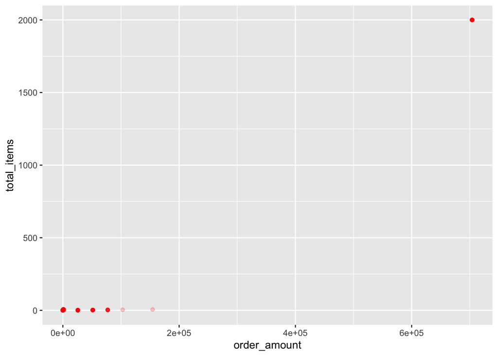

```r
# be consistent with associating function with package
gg$ggplot(data = df_sales,
          mapping = gg$aes(x = order_amount, y = total_items)) +
    gg$geom_point(alpha = 0.2, colour="red") +
    # the next two were initally missing `gg$`
    gg$xlim(0,704000) +
    gg$ylim(0,2000)
```

# Example 4

# the number seems problematic and we will explore another measure of central tendency - a median. Median is preferable when some extreme values are present in a data set.

```r
 median(df_sales$order_amount)

#The resulting number show us that the variability is extreme in the data since median value is very different from average value so we should continue exploring the data to obtain more useful sales picture
```

```
[1] 284
```

## We identify three columns of the data frame as relevant for our analysis and will proceed to tidy up df_sales by eliminating several columns

```r
df_sales_tidy <- df_sales %>%
  dp$select(-order_id, -payment_method, - created_at, -user_id)
df_sales_tidy
```

```
# A tibble: 5,000 x 3
   shop_id order_amount total_items
     <int>        <dbl>       <int>
 1      53          224           2
 2      92           90           1
 3      44          144           1
 4      18          156           1
 5      18          156           1
 6      58          138           1
 7      87          149           1
 8      22          292           2
 9      64          266           2
10      52          146           1
# … with 4,990 more rows
```

# To better examine the tidy frame

# We arrange the date frame to observe variability in total items first

```r
df_sales_tidy %>%
  dplyr::arrange(desc(total_items))
```

```
# A tibble: 5,000 x 3
   shop_id order_amount total_items
     <int>        <dbl>       <int>
 1      42       704000        2000
 2      42       704000        2000
 3      42       704000        2000
 4      42       704000        2000
 5      42       704000        2000
 6      42       704000        2000
 7      42       704000        2000
 8      42       704000        2000
 9      42       704000        2000
10      42       704000        2000
# … with 4,990 more rows
```

# we can see that some shops have highly divergent values for total items

…

# The original AOV value $3145.13 was calculated by applying the formula to the raw data. When we applied a different mesure of central tendency to the data, a median, we observed a value of AOV = $284. The divergence of values indicated the presence of extreme values possibly distorting even a median calculation.

# We proceeded to tidy the data by grouping and arranging data for two relevant variables order_amount and total_items and found two shops with outlier values : one for total_items and the other for order_amount(where the price_per_item was extreme outlier)

# We eliminated two shops data that were skewing the calculations and we believe that the resulting value of AOV = 299.6824 is a better representation of the sneakers sales data distribution for the month